# Sequence to Sequence Model

Ahmad Husain Abdullah

December 26, 2018

In this article, We will go through explanation about sequence to sequence model. After completing this tutorial, you will know:

- Quick review why Recurrent Neural Network instead of Vanilla Neuaral Network for sequential set data.
- Sequence to sequence model implementation in a various business.
- Many type of text data vectorization in sequence to sequence model.
- The different of Abstractive and Extractive summarization.
- How to build encoder-decoder architecture for text summarization.

I recommend that you have (prerequisites):

- Familiarity with R programming
- Familiarity with neural network and in particular, Recurrent Neural Networks (RNNs). If you are not yet familiear with RNNs, I recommend reading the RNN section which will give you quick start. For you who want to dive deep to RNN architecture please look up to [this article](https://algotech.netlify.com/blog/text-lstm/).

# Text Summarization

*Text summarization* is a branch in natural language processing (NLP) to generate a shorter and concise version of a text while preserving the meaning of the original text. Text summarization is nowadays has been applied in a lot of business, for example, news websites that use *text summarization* to give the readers an overview of what a particular article talk about.

> **Goal**: reducing a text with a computer program in order to create summary that retain the most important points of the original text.

Automatic text summarization is very challenging, because we as humans summarize a piece of text, we usually read it entirely to develop our understanding, and then write a summary highlighting its main point. Since computers lack human knowledge and language capability, it make text summarization a very difficult and non-trivial task[^2].

Based on a paper by [Gaikwad, D (2016)](https://pdfs.semanticscholar.org/0681/b372590f7cccc049d24bbddcfb31b68cce61.pdf), text summarizers identify and extract key sentence from the source text and concatenat them to form a concise summary. Below is a list of feature for text summarization [^3].

- **Term Frequency**: The frequently occurring word increases score of sentences. The most common measure widely used to calculate the word frequency is *Term Fequence Inverse Document Frequence* (TF IDF).
- **Location**: It depends on the intuition that inportant sentences are located at certain position in text or in paragraph. First and last sentence of paragraph has greater chance to be included in summary.
- **Cue Method**: Effect of positive or negativity of word on the sentence weight to indicate importance or key idea such as cues: *‘in summary’*, *‘in conclusion’*, *‘the paper describes’*.
- **Title/Headline**: Words in the title and heading of document that occur in sentences are positively related to summarization. Words that appear in the title are also indicative of the topic or subject of the document.
- **Sentence length**: Keeps in view the size of summary. Generally, very long and very short sentences are also not suitable for summary.
- **Similarity**: Similarity can be calculated with linguistic knowledge. it indicated similarity between the sentence antitle of the document, and similarity between the sentence and remaining sentence of the docment.
- **Proper noun**: For document summarization sentences having proper nouns are important. Like name of a person, place or organizaation.
- **Proximity**: The distance berween text units where entities occur is determining factor for establishing relation between entities.

## Text Summarization Method

In general, there are two difference approaches for text summarization:

1. Extractive summarization
2. Abstractive summarization

### Extractive Method

Extracting text summarization algoritmh are capable of *extracting* key sentence from a text without modifying any word. They depend only on extraction of sentences from the original text.

> Selecting set of sentences from the source text, then arranging them to form a summary.

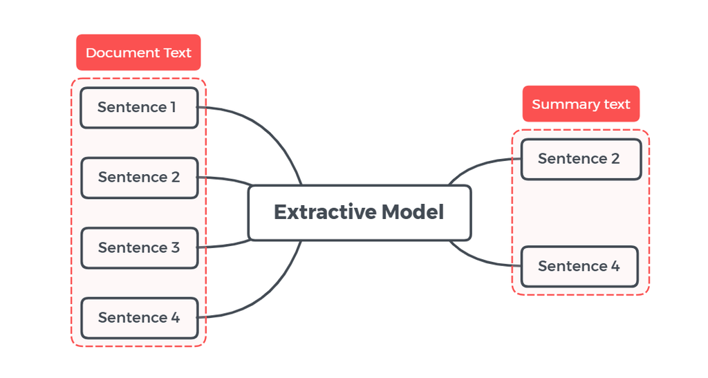

Fig 1. Extractive Summarization Idea

Methods:

1. Lhun
2. TextRank
3. SumBasic
4. Edmunson
5. LexRank
6. Latent Semantic Analysis

### Abstractive Methods

Abstractive methods need a deeper analysis of the text. These methods have ability to generate a new sentance, which improves the context of a summary, reduce its redundancy and keep a good compression rate.

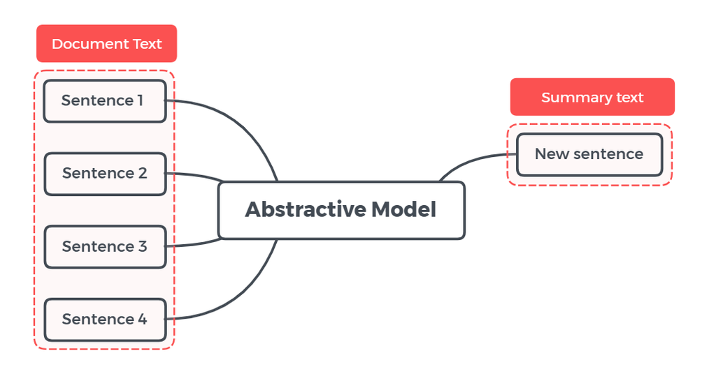

Fig 2. Abstractive Summarization Idea

Methods:

1. **Sequence to Sequence Model**
2. Sequence to Sequence with attention
3. Pointer Generation Network
4. Fast Abstractive Reinforcement

On this article we more focused on abstractive methods with RNN sequence to sequence model:

# Sequence to Sequence Method

A lot of algorithms for both extractive and abstractive text summarization are based on Recurrent Neural Networks(RNN). Furthermore, using RNNs in an Encoder-Decoder manner leads us to the well known Sequence-To-Sequence (Seq2Seq) architecture [^1]. A sequence to sequence model lies to numerous system which we face on a daily basis. For example, seq2seq model powers application like *Google Translate* (machine translation), voice-enabled device (speech recognation), video captioning, and online chatbots.

# Recurrent Neural Network

We know that neural network uses an algorithm called **Backpropagation** to update the weights of the network. So what Backpropogation does is it first calculates the gradients from the error using the chain rule, then in updates the weights (*Gradient Descent*).

When doing backpropogation in simple neural network (1 hidden layer) we might not encounter the problem update weights. But….

> When we build an architecture with a large number of hidden layer (Deep Neural Network) the model is likely to encounter update weight problem called *vanishing* / *exploding* gradient descent.

**Vanishing Gradient Descent**: the update value obtained will exponentially decrease when heading to the input layer. Here are the illustrations, which I took from: [Michael Nguyen’s article](https://towardsdatascience.com/illustrated-guide-to-recurrent-neural-networks-79e5eb8049c9)

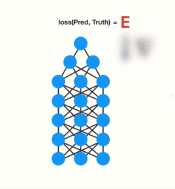

Gradient descent aims to adjust weights that allow the model to ‘**learn**’. the nature of the gradient that is, the greater the value of the gradient in the current layer, will affect in the next layer getting bigger. and *vice versa*. This is the problem. When doing BP, each node will calculate the gradient value and update its weight according to the gradient effect on the previous layer. so if the previous layer is small, then adjusting the weights in the current layer will be small. it causes the gradient to shrink exponentially when it goes to the input layer. so that when in the input layer it fails to do the learning due to *vanishing gradient problems*. so the model **fails to learn** when a pass forward is made again to make predictions.

**Exploding Gradient Descent**: the update value obtained will exponentially increase when heading to the input layer. The characteristics of the model have an exploding gradient problem, which is when the cost function results are NaN.

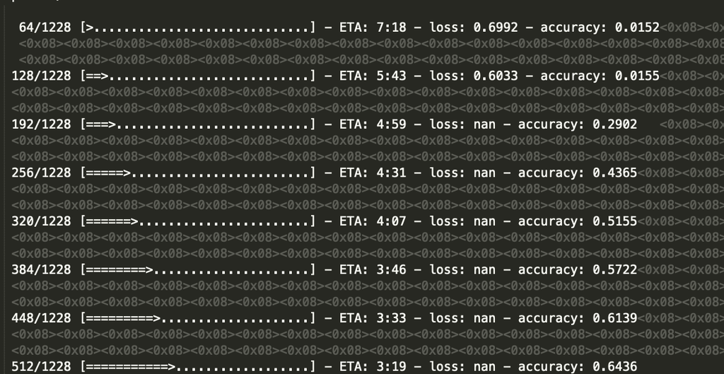

## What is Seq2Seq method?

Introduced for the first time in 2014 by [Google](https://arxiv.org/pdf/1409.3215.pdf), a sequence to sequence model aims to map a fixed-length input with a fixed length output where the length of input and output may differ. For example, translating “*How are you?*” from English to Indonesian has input of 3 words words and output 2 words “*Apa kabar?*”. So, we can’t use a reguler LSTM network to map each word from the English sentence to the Indonesian sentence. This is why sequence to sequence model is used to address the problem like that.

## Encoder-Decoder Model

The most common architecture use to build Seq2Seq models is the Encoder Decoder architecture. In order to understand the architecture’s underlying logic, we will go over the below illustration:

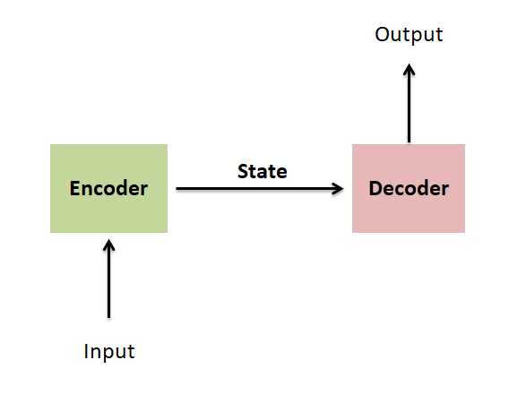

Fig 3. Encoder-decoder sequence to sequence model

Above, a simple Seq2Seq model consists of three parts, Encoder-LSTM, Decoder-LSTM, and State also known as the context.

Point to note:

- Both encoder and decoder are RNN models (more often LSTM).
- **Encoder**: The encoder reads the entire input sequence and encodes it into an internal representation, often a fixed-length vector called the context vector.
- **Decoder**: The decoder reads the encoded input sequence from the encoder and generates the output sequence.
- The decoder behaves a bit differently during the training and inference procedure. During the training, we use a technique call teacher forcing which helps to train the decoder faster. During inference, the input to the decoder at each time step is the output from the previous time step.

> …RNN Encoder-Decoder, consists of two recurrent neural networks (RNN) that act as an encoder and a decoder pair. The encoder maps a variable-length source sequence to a fixed-length vector, and the decoder maps the vector representation back to a variable-length target sequence [^4].

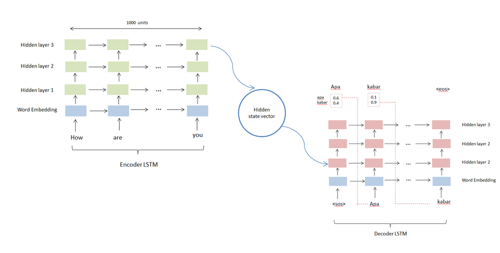

Fig 4. Encoder-decoder example architecture

Now, we will understand all the above steps, taken from [this article](https://towardsdatascience.com/word-level-english-to-marathi-neural-machine-translation-using-seq2seq-encoder-decoder-lstm-model-1a913f2dc4a7). We will keep this section intuitive without going to mathematical detail. So here is the main idea of encoder architecture:

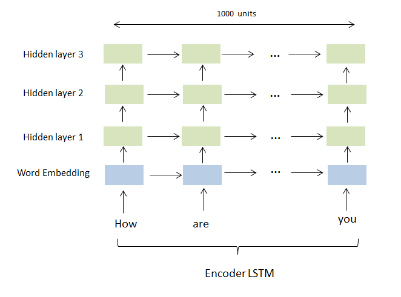

Fig 5. Encoder model

The LSTM reads the data one sequence after the other. Thus if the input is a sequence of length ‘k’, we say that LSTM reads it in ‘k’ time steps. Because we have sentences with 3 words, “How”, “are”, you" the LSTM will read the sentence word by word in 3 time steps as above. The words embedding layer is a technique to represent the words ($x_i$) as a vector. There are various word embedding techniques which map (embed) a word into a fixed length vector. In this tutorial we’ll use pre-trained embedding vector from [*Conceptnet Numberbatch’s (CN)*](https://github.com/commonsense/conceptnet-numberbatch) similar to GloVe, but probably better.

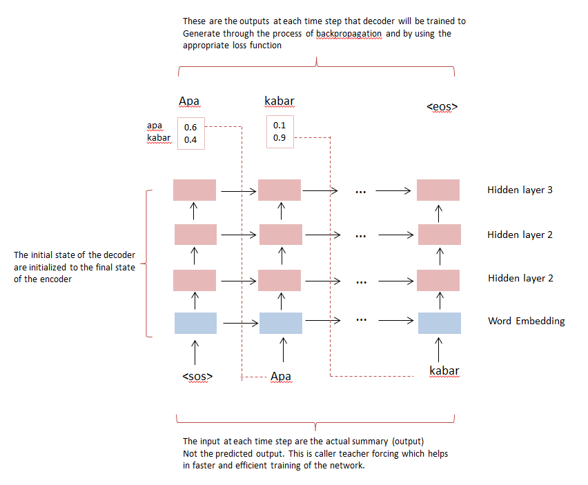

Fig 5. Decoder model

Unlike the Encoder LSTM which has the same role to play in both the training phase as well as in the inference phase, the Decoder LSTM has a slightly different role to play in both of these phases. In this section we’ll try to understand how to configure the Decoder during the training phase, while in the next section we’ll understand how to use it during inference.

> The most important point is that the initial states (h0, c0) of the decoder are set to the final states of the encoder. This intuitively means that the decoder is trained to start generating the output sequence depending on the information encoded by the encoder. Obviously the translated Indonesian sentence must depend on the given English sentence.

In the first time step we provide the or START_ token so that the decoder starts generating the next token (the actual first word of Indonesian sentence). And after the last word in the Indonesian sentence, we make the decoder learn to predict the or _END token. This will be used as the stopping condition during the inference procedure, basically it will denote the end of the translated sentence and we will stop the inference loop (more on this later).

We use a technique called “Teacher Forcing” wherein the input at each time step is given as the actual output (and not the predicted output) from the previous time step. This helps in more faster and efficient training of the network (https://machinelearningmastery.com/teacher-forcing-for-recurrent-neural-networks/).

Inference phase, taken from [this article:](https://towardsdatascience.com/word-level-english-to-marathi-neural-machine-translation-using-seq2seq-encoder-decoder-lstm-model-1a913f2dc4a7)

1. During inference, we generate one word at a time. Thus the Decoder LSTM is called in a loop, every time processing only one time step.
2. The initial states of the decoder are set to the final states of the encoder.
3. The initial input to the decoder is always the START_ token.
4. At each time step, we preserve the states of the decoder and set them as initial states for the next time step.
5. At each time step, the predicted output is fed as input in the next time step.
6. We break the loop when the decoder predicts the END_ token.

Both the encoder and the decoder submodels are trained jointly, meaning at the same time. The entire encoded input is used as context for generating each step in the output. The output sequence relies heavily on the context defined in the final output of the encoder, making it challenging for the model to deal with long sentences. In the case of long sequences, there is a high probability that the initial context has been lost by the end of the sequence. Because it becomes difficult for the encoder to memorize the entire sequence into a fixed-sized vector and to compress all the contextual information from the sequence. As we observed that as the sequence size increases model performance starts getting degrading. An extension of the Encoder-Decoder architecture is to provide a more expressive form of the encoded input sequence and allow the decoder to learn where to pay attention to the encoded input when generating each step of the output sequence. This extension of the architecture is called **attention** [^5].

> *Solution to deal with long sentences:* Bahdanau et al., 2014 and Luong et al., 2015 papers introduced and a technique called “Attention” which allows the model to focus on different parts of the input sequence at every stage of the output sequence allowing the context to be preserved from beginning to end [^9].

So in this attention mechanism, taken from [this article](https://medium.com/analytics-vidhya/intuitive-understanding-of-seq2seq-model-attention-mechanism-in-deep-learning-1c1c24aace1e) give importance to specific parts of the sequence instead of the entire sequence predict that word. Basically, in the attention, we don’t throw away the intermediate from the encoder state but we utilize this to generate context vector from all states so that the decoder gives output result.

Let’s go through an example to understand how attention mechanism works:

- Source sequence: “Which sport do you like the most?
- Target sequence: “I love cricket”

So the idea of attention was to utilize all the contextual information from the input sequence so that we can decode our target sequence. Let’s look at the example we mention. The first word ‘I’ in the target sequence is connected to the fourth word ‘you’ in the source sequence, right? Similarly, the second-word ‘love’ in the target sequence is associated with the fifth word ‘like’ in the source sequence. As we can observe that we are paying more attention to context information like sports, like, you in the source sequence. So, instead of going through the entire sequence it pays attention to specific words from the sequence and gives out the result based on that.

# Implementing Text Summarization using Tensorflow

```r
library(reticulate)
```

```python
import pandas as pd
import numpy as np
import tensorflow as tf
import re
from nltk.corpus import stopwords
import time
from tensorflow.python.layers.core import Dense
from tensorflow.python.ops.rnn_cell_impl import _zero_state_tensors
print('TensorFlow Version: {}'.format(tf.__version__))
```